# Demonstration of K-Nearest Neighbors

JAS

## Demonstration of K Nearest Neighbors

Using the caret package to implement KNN.

Data Description:

Data come from the UCI Machine Learning Repository. This is a dataset containing clinical information about individuals who are either blood donors (i.e. healthy controls) or have varying severity of liver disease.

Data Set Information:

The target attribute for classification is Category (blood donors vs. Hepatitis C (including its progress (‘just’ Hepatitis C, Fibrosis, Cirrhosis).

Attribute Information:

All attributes except Category and Sex are numerical. The laboratory data are the attributes 5-14. 1. X (Patient ID/No.) 2. Category (diagnosis) (values: ‘0=Blood Donor’, ‘0s=suspect Blood Donor’, ‘1=Hepatitis’, ‘2=Fibrosis’, ‘3=Cirrhosis’) 3. Age (in years) 4. Sex (f,m) 5. ALB 6. ALP 7. ALT 8. AST 9. BIL 10. CHE 11. CHOL 12. CREA 13. GGT 14. PROT

### Load Needed Packages

```r
library(dplyr)
library(caret)
library(klaR)
library(dplyr)
library(forcats)
library(here)
```

### Cleaning and partitioning data

Because knn is distance-based and we are using Euclidian distance, we *theoretically* only want to include numerical (continuous) features. However, we can convert our factor variables to 0/1 numerical indicators and this will enable us to use these features while still using Euclidian distance. If you have only categorical features within a dataset, one could use a different distance metric (e.g. Hamming distance).

For the purpose of this demonstration, We will collapse the outcome classification into a binary (Liver Disease, No Evidence of Disease). We are also excluding individuals with missing data.

Also, note that the data are very imbalanced (i.e. the target class is <35% of the full sample). Thus, I will demonstrate how to incorporate sampling within the training step.

```r
set.seed(123)

hcvdat0 <- read.csv(here("data-raw//hcvdat0.csv"))

#Look at features
str(hcvdat0)
```

```
## 'data.frame':    615 obs. of  14 variables:
##  $ X       : int  1 2 3 4 5 6 7 8 9 10 ...
##  $ Category: chr  "0=Blood Donor" "0=Blood Donor" "0=Blood Donor" "0=Blood Donor" ...
##  $ Age     : int  32 32 32 32 32 32 32 32 32 32 ...
##  $ Sex     : chr  "m" "m" "m" "m" ...
##  $ ALB     : num  38.5 38.5 46.9 43.2 39.2 41.6 46.3 42.2 50.9 42.4 ...
##  $ ALP     : num  52.5 70.3 74.7 52 74.1 43.3 41.3 41.9 65.5 86.3 ...
##  $ ALT     : num  7.7 18 36.2 30.6 32.6 18.5 17.5 35.8 23.2 20.3 ...
##  $ AST     : num  22.1 24.7 52.6 22.6 24.8 19.7 17.8 31.1 21.2 20 ...
##  $ BIL     : num  7.5 3.9 6.1 18.9 9.6 12.3 8.5 16.1 6.9 35.2 ...
##  $ CHE     : num  6.93 11.17 8.84 7.33 9.15 ...
##  $ CHOL    : num  3.23 4.8 5.2 4.74 4.32 6.05 4.79 4.6 4.1 4.45 ...
##  $ CREA    : num  106 74 86 80 76 111 70 109 83 81 ...
##  $ GGT     : num  12.1 15.6 33.2 33.8 29.9 91 16.9 21.5 13.7 15.9 ...
##  $ PROT    : num  69 76.5 79.3 75.7 68.7 74 74.5 67.1 71.3 69.9 ...
```

```r
#Omit those with missing data
hcvdata<-na.omit(hcvdat0)

#drop ID variables
hcvdata$X<-NULL

#Convert sex assignment to a numeric indicator 0-male/1-female

hcvdata$female<-ifelse(hcvdata$Sex=="f", 1, 0)
hcvdata$Sex<-NULL


#Make outcome category a factor var
hcvdata$Category<-as.factor(hcvdata$Category)

#Collapse factor levels of outcome variable
hcvdata$outcome.class<-fct_collapse(hcvdata$Category, NED=c("0=Blood Donor","0s=suspect Blood Donor"), LiverDisease=c("1=Hepatitis", "2=Fibrosis", "3=Cirrhosis"))

#Drop category
hcvdata$Category<-NULL

#Check distributions etc. Note how rare the target label (i.e. LiverDisease) is within the dataset
summary(hcvdata)
```

```
##       Age             ALB             ALP              ALT
##  Min.   :23.00   Min.   :14.90   Min.   : 11.30   Min.   :  0.90
##  1st Qu.:39.00   1st Qu.:38.80   1st Qu.: 52.50   1st Qu.: 16.40
##  Median :47.00   Median :41.90   Median : 66.20   Median : 22.70
##  Mean   :47.42   Mean   :41.62   Mean   : 68.12   Mean   : 26.58
##  3rd Qu.:54.00   3rd Qu.:45.10   3rd Qu.: 79.90   3rd Qu.: 31.90
##  Max.   :77.00   Max.   :82.20   Max.   :416.60   Max.   :325.30
##       AST              BIL              CHE              CHOL
##  Min.   : 10.60   Min.   :  0.80   Min.   : 1.420   Min.   :1.430
##  1st Qu.: 21.50   1st Qu.:  5.20   1st Qu.: 6.930   1st Qu.:4.620
##  Median : 25.70   Median :  7.10   Median : 8.260   Median :5.310
##  Mean   : 33.77   Mean   : 11.02   Mean   : 8.204   Mean   :5.391
##  3rd Qu.: 31.70   3rd Qu.: 11.00   3rd Qu.: 9.570   3rd Qu.:6.080
##  Max.   :324.00   Max.   :209.00   Max.   :16.410   Max.   :9.670
##       CREA              GGT             PROT           female
##  Min.   :   8.00   Min.   :  4.5   Min.   :44.80   Min.   :0.0000
##  1st Qu.:  68.00   1st Qu.: 15.6   1st Qu.:69.30   1st Qu.:0.0000
##  Median :  77.00   Median : 22.8   Median :72.10   Median :0.0000
##  Mean   :  81.67   Mean   : 38.2   Mean   :71.89   Mean   :0.3837
##  3rd Qu.:  89.00   3rd Qu.: 37.6   3rd Qu.:75.20   3rd Qu.:1.0000
##  Max.   :1079.10   Max.   :650.9   Max.   :86.50   Max.   :1.0000
##       outcome.class
##  NED         :533
##  LiverDisease: 56
##
##
##
##
```

```r
#Split data 70/30
train.indices<-hcvdata$outcome.class %>% createDataPartition(p=0.7, list=F)

train.data<-hcvdata[train.indices, ]
test.data<-hcvdata[-train.indices, ]
```

### Train and assess performance of model

We will use 10-fold cross validation to compare 10 different values of k. We will also use under-sampling due to the imbalance of the data.

```r
set.seed(123)

#Set control options..using 10-fold cross-validation and using sampling due to unbalanced data
trnctrl<-trainControl(method="cv", number=10, sampling="down")

knn.model.1<-train(
                    outcome.class~.  ,
                    data=train.data,
                    method="knn",
                    trControl=trnctrl,
                    preProcess=c("center", "scale"),
                    tuneLength=10)

#Identify optimal number of k
knn.model.1$bestTune
```

```
##    k
## 4 11
```

```r
#See full set of results
knn.model.1$results
```

```
##     k  Accuracy     Kappa AccuracySD   KappaSD
## 1   5 0.9298490 0.6141088 0.04038573 0.2230528
## 2   7 0.9371661 0.6073645 0.02043057 0.1455590
## 3   9 0.9396632 0.6409174 0.04157950 0.2443684
## 4  11 0.9445412 0.6176660 0.03406589 0.2301138
## 5  13 0.9226481 0.5448761 0.06676783 0.2759178
## 6  15 0.9395470 0.5925950 0.03300917 0.2079203
## 7  17 0.9421603 0.5637444 0.01987349 0.1915646
## 8  19 0.9276423 0.4040421 0.02750813 0.2791340
## 9  21 0.9372242 0.4654496 0.02024753 0.2346992
## 10 23 0.9252033 0.3589172 0.02623730 0.2570054
```

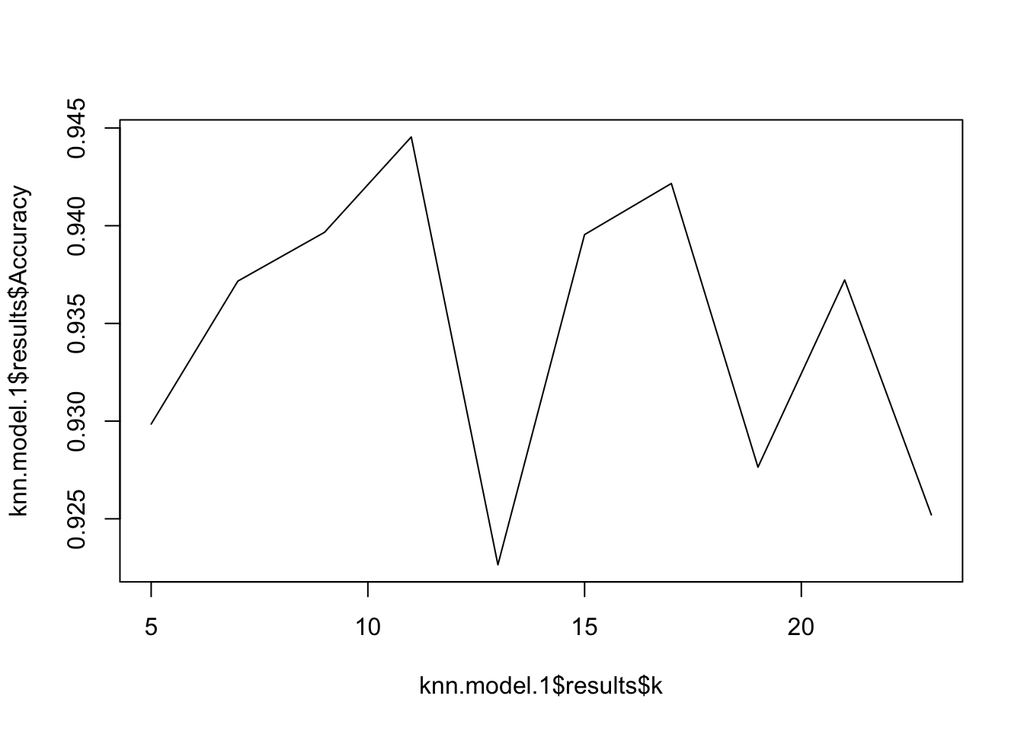

```r
plot(knn.model.1$results$k, knn.model.1$results$Accuracy, type="l")
```

```r
#REPEAT using over-sampling due to unbalanced data

set.seed(123)
trnctrl<-trainControl(method="cv", number=10, sampling="up")

knn.model.2<-train(
                    outcome.class~.  ,
                    data=train.data,
                    method="knn",
                    trControl=trnctrl,
                    preProcess=c("center", "scale"),
                    tuneLength=10)

#REPEAT using your own vector of K-values

k.vec<-seq(1,10,1)
set.seed(123)
knn.model.3<-train(
                    outcome.class~.  ,
                    data=train.data,
                    method="knn",
                    trControl=trnctrl,
                    preProcess=c("center", "scale"),
                    tuneGrid=expand.grid(k=k.vec))

#Identify optimal number of k
knn.model.3$bestTune
```

```
##   k
## 4 4
```

```r
#See full set of results
knn.model.3$results
```

```
##     k  Accuracy     Kappa AccuracySD   KappaSD
## 1   1 0.9444832 0.5770713 0.02542260 0.2113159
## 2   2 0.9517422 0.6549166 0.03571672 0.2372876
## 3   3 0.9517422 0.6882896 0.03180081 0.2025665
## 4   4 0.9517422 0.7039581 0.03180081 0.1805600
## 5   5 0.9493612 0.7123442 0.03968282 0.2051283
## 6   6 0.9468641 0.7006812 0.03897825 0.2144399
## 7   7 0.9444832 0.6988642 0.03581076 0.1926832
## 8   8 0.9325784 0.6648044 0.05272553 0.2230569
## 9   9 0.9371661 0.6871531 0.04133125 0.1882301
## 10 10 0.9300232 0.6497509 0.03967569 0.1898856
```

```r
confusionMatrix(knn.model.3)
```

```
## Cross-Validated (10 fold) Confusion Matrix
##
## (entries are percentual average cell counts across resamples)
##
##               Reference
## Prediction      NED LiverDisease
##   NED          88.4          2.9
##   LiverDisease  1.9          6.8
##
##  Accuracy (average) : 0.9517
```

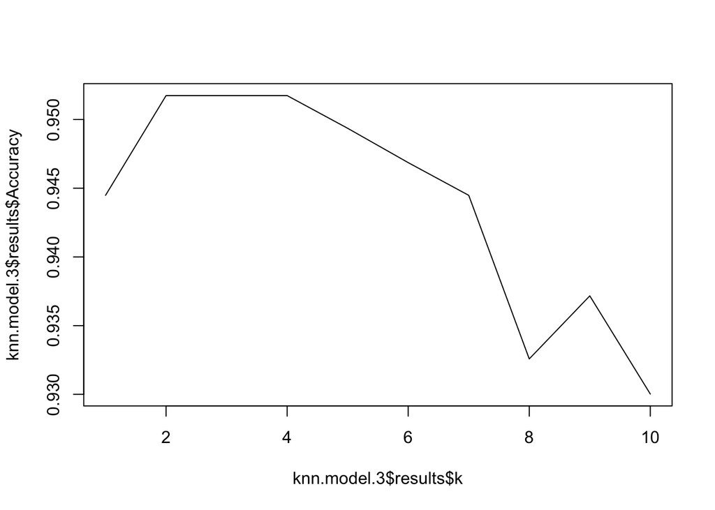

```r
plot(knn.model.3$results$k, knn.model.3$results$Accuracy, type="l")
```

### Make predictions in test-set optimal k

```r
model.results.3<-predict(knn.model.3, newdata=test.data)
confusionMatrix(model.results.3, test.data$outcome.class, positive="LiverDisease")
```

```
## Confusion Matrix and Statistics
##
##               Reference
## Prediction     NED LiverDisease
##   NED          154            1
##   LiverDisease   5           15
##
##                Accuracy : 0.9657
##                  95% CI : (0.9269, 0.9873)
##     No Information Rate : 0.9086
##     P-Value [Acc > NIR] : 0.002904
##
##                   Kappa : 0.8145
##
##  Mcnemar's Test P-Value : 0.220671
##
##             Sensitivity : 0.93750
##             Specificity : 0.96855
##          Pos Pred Value : 0.75000
##          Neg Pred Value : 0.99355
##              Prevalence : 0.09143
##          Detection Rate : 0.08571
##    Detection Prevalence : 0.11429
##       Balanced Accuracy : 0.95303
##
##        'Positive' Class : LiverDisease
##
```